# COMP41680/COMP47670 Assignment 1 Sample - Task 2 + 3

In this assignment we will collect detailed hourly weather data from the [AccuWeather open web API](https://developer.accuweather.com) for four different locations (Dublin, Lisbon, London, and Rome).

We will use all of the JSON data collected during Task 1 to perform the analysis process.

```python
import json
from pathlib import Path
from datetime import datetime
import pandas as pd
from sklearn.metrics.pairwise import euclidean_distances
import matplotlib
import matplotlib.pyplot as plt
import matplotlib.dates as mdates
import matplotlib.ticker as ticker
from pandas.plotting import scatter_matrix
import seaborn as sns
%matplotlib inline
```

Key settings, including our list of cities and various appearance settings for plotting later:

```python
# The city locations that we would like to study
city_names = ["Dublin", "Lisbon", "London", "Rome"]
# Precision that we'll use for Pandas display
pd.set_option('precision', 2)
# Colors that we will use in various plots
city_colors = {"Dublin":"green", "Lisbon":"darkred", "London":"orange", "Rome":"navy"}
# Default font size
fontsize = 13
```

Directories for data storage:

```python
# directory for raw data storage
dir_raw = Path("raw")
# directory for storing clean pre-processed data
dir_data = Path("data")
# make sure it exists
dir_data.mkdir(parents=True, exist_ok=True)
```

## Data Preprocessing

Before we can analyse the data, we need to transform it into a usable format.

Firstly, find all of the raw JSON files and separate them by city:

```python
city_files = {}
for city_name in city_names:
    city_files[city_name] = []
for fpath in dir_raw.iterdir():
    if fpath.suffix == ".json":
        # parse the filename
        parts = fpath.stem.split("-")
        if parts[0] in city_names:
            city_files[parts[0]].append(fpath)
for city_name in city_names:
    print("%s: Found %d raw data files" % (city_name, len(city_files[city_name])))
```

```
Dublin: Found 19 raw data files
Lisbon: Found 19 raw data files
London: Found 19 raw data files
Rome: Found 19 raw data files
```

### Data Parsing and Merging

We will define a function that will parse an individual raw JSON data file coming from the Accuweather API.

An important aspect with this API is how we handle dates and times. Note that AccuWeather provides forecasts at different times per hour, so we will round each date to the nearest hour. Also, since we want to compare equivalent times in different location, we strip the time zone information.

```python
def round_datetime(obs_date):
    # round and convert to a Pandas TimeStamp
    ts = pd.Timestamp(obs_date)
    return ts.round(freq="H")
```

```python
def parse_raw_data(city_name, fpath):
    fin = open(fpath, "r")
    jdata = fin.read()
    data = json.loads(jdata)
    # handle each observation
    rows = []
    for obs in data:
        row = {"City": city_name}
        # parse the local datatime in ISO8601 format
        obs_date = datetime.strptime(obs["LocalObservationDateTime"], "%Y-%m-%dT%H:%M:%S%z")
        # strip the timezone
        obs_date = obs_date.replace(tzinfo=None)
        # round it to the nearest hour
        row["Date"] = round_datetime(obs_date)
        # add temperature data, in celsius - both raw and 'feels like' with wind chill
        row["Temperature"] = obs["ApparentTemperature"]["Metric"]["Value"]
        row["WindChillTemperature"] = obs["WindChillTemperature"]["Metric"]["Value"]
        # add precpipation level, in mm for last hour
        row["PrecipitationLevel"] = obs["Precip1hr"]["Metric"]["Value"]
        # add wind speed
        row["Wind"] = obs["Wind"]["Speed"]["Metric"]["Value"]
        # add relative humidity
        row["Humidity"] = obs["RelativeHumidity"]
        # add cloud cover, as a float representing percentage
        row["CloudCover"] = float(obs["CloudCover"])/100
        # add other fields
        row["Description"] = obs["WeatherText"]
        rows.append(row)
    fin.close()
    # return back the DataFrame
    return pd.DataFrame(rows)
```

Define a function that will parse and merge a collection of raw data files:

```python
def parse_merge_raw_data(city_name, fpaths):
    df_files = []
    # process each file for this city
    print("Reading and parsing %d JSON data files ..." % len(fpaths))
    for fpath in fpaths:
        # produce a DataFrame from this file
        df_file = parse_raw_data(city_name, fpath)
        df_files.append(df_file)
    # concatenate all the DataFrames together into a single frame
    df_city = pd.concat(df_files)
    # next we remove duplicate observations based on the Date field
    df_city.drop_duplicates(subset="Date", keep="first", inplace=True)
    # now set the index column to be the Date, which is now unique
    df_city.set_index("Date", inplace=True)
    # we will also sort the frame by its index
    return df_city.sort_index()
```

Parse and merge the raw data files for each city, producing a single merged Pandas Data Frames for each city which we can analyse later on:

```python
df_cities = {}
for city_name in city_names:
    print("-- %s" % city_name)
    df_city = parse_merge_raw_data(city_name, city_files[city_name])
    df_cities[city_name] = df_city
```

```
-- Dublin
Reading and parsing 19 JSON data files ...
-- Lisbon
Reading and parsing 19 JSON data files ...
-- London
Reading and parsing 19 JSON data files ...
-- Rome
Reading and parsing 19 JSON data files ...
```

### Data Verification

Check the format of one of the newly-created city Data Frames:

```python
df_cities["Dublin"].head(5)
```

| Date | City | Temperature | WindChillTemperature | PrecipitationLevel | Wind | Humidity | CloudCover | Description |
| --- | --- | --- | --- | --- | --- | --- | --- | --- |
| 2021-10-02 11:00:00 | Dublin | 13.9 | 11.1 | 0.0 | 14.8 | 81 | 0.91 | Cloudy |
| 2021-10-02 12:00:00 | Dublin | 15.0 | 12.2 | 0.0 | 18.5 | 75 | 0.63 | Light rain |
| 2021-10-02 13:00:00 | Dublin | 15.0 | 12.2 | 0.0 | 18.5 | 74 | 0.76 | Mostly cloudy |
| 2021-10-02 14:00:00 | Dublin | 12.8 | 6.7 | 0.3 | 31.5 | 85 | 0.76 | Mostly cloudy |
| 2021-10-02 15:00:00 | Dublin | 16.1 | 12.8 | 0.3 | 22.2 | 70 | 0.88 | Mostly cloudy |

Check the number of rows and date ranges in the DataFrames:

```python
def summarize_dates():
    rows = []
    for city_name in city_names:
        row = {"City": city_name}
        row["Rows"] = len(df_cities[city_name])
        row["DateStart"] = df_cities[city_name].index.min()
        row["DateEnd"] = df_cities[city_name].index.max()
        rows.append(row)
    return pd.DataFrame(rows).set_index("City")

# display the ranges
df_date_summary = summarize_dates()
df_date_summary
```

| City | Rows | DateStart | DateEnd |
| --- | --- | --- | --- |
| Dublin | 216 | 2021-10-02 11:00:00 | 2021-10-11 11:00:00 |
| Lisbon | 216 | 2021-10-02 11:00:00 | 2021-10-11 11:00:00 |
| London | 216 | 2021-10-02 11:00:00 | 2021-10-11 11:00:00 |
| Rome | 216 | 2021-10-02 12:00:00 | 2021-10-11 12:00:00 |

We will standardise the date range across all locations, so that all DataFrames have the same start date and end date:

```python
# find the latest start date
date_start = df_date_summary["DateStart"].max()
# find the earlier end date
date_end = df_date_summary["DateEnd"].min()
date_start, date_end
```

```
(Timestamp('2021-10-02 12:00:00'), Timestamp('2021-10-11 11:00:00'))
```

```python
# truncate each dataset
for city_name in city_names:
    df_cities[city_name] = df_cities[city_name][date_start:date_end]
# check the date ranges again
summarize_dates()
```

| City | Rows | DateStart | DateEnd |
| --- | --- | --- | --- |
| Dublin | 215 | 2021-10-02 12:00:00 | 2021-10-11 11:00:00 |
| Lisbon | 215 | 2021-10-02 12:00:00 | 2021-10-11 11:00:00 |
| London | 215 | 2021-10-02 12:00:00 | 2021-10-11 11:00:00 |
| Rome | 215 | 2021-10-02 12:00:00 | 2021-10-11 11:00:00 |

Next, we check to see if we have any missing value in any of our DataFrames:

```python
for city_name in city_names:
    print("-- %s" % city_name)
    missing_counts = df_cities[city_name].isnull().sum()
    # which coludmns have missing values?
    missing_counts = missing_counts[missing_counts>0]
    if len(missing_counts) == 0:
        print("No missing values found")
    else:
        print(missing_counts)
```

```
-- Dublin
No missing values found
-- Lisbon
No missing values found
-- London
No missing values found
-- Rome
No missing values found
```

### Data Saving

Now write out all of the merged city DataFrames in JSON format, one file per city. These will represent the 'clean' data that we will use next for our actual data analysis:

```python
for city_name in city_names:
    fname = "%s.json" % city_name
    out_path = dir_data / fname
    print("Writing %s" % out_path)
    df_cities[city_name].to_json(out_path, orient="index", indent=4)
```

```
Writing data/Dublin.json
Writing data/Lisbon.json
Writing data/London.json
Writing data/Rome.json
```

## Data Analysis

### Data Loading

We will reload the city data frames that we stored previously. Note that we could skip this step.

```python
df_cities = {}
for city_name in city_names:
    fname = "%s.json" % city_name
    in_path = dir_data / fname
    df_cities[city_name] = pd.read_json(in_path, orient="index")
    print("%s: %d rows of data - [%s to %s]" %
          (city_name, len(df_cities[city_name]),
           df_cities[city_name].index.min(), df_cities[city_name].index.max() ))
```

```
Dublin: 215 rows of data - [2021-10-02 12:00:00 to 2021-10-11 11:00:00]
Lisbon: 215 rows of data - [2021-10-02 12:00:00 to 2021-10-11 11:00:00]
London: 215 rows of data - [2021-10-02 12:00:00 to 2021-10-11 11:00:00]
Rome: 215 rows of data - [2021-10-02 12:00:00 to 2021-10-11 11:00:00]
```

Check the format of one of the newly-read city Data Frames:

```python
df_cities["Dublin"].head(5)
```

|  | City | Temperature | WindChillTemperature | PrecipitationLevel | Wind | Humidity | CloudCover | Description |
| --- | --- | --- | --- | --- | --- | --- | --- | --- |
| 2021-10-02 12:00:00 | Dublin | 15.0 | 12.2 | 0.0 | 18.5 | 75 | 0.63 | Light rain |
| 2021-10-02 13:00:00 | Dublin | 15.0 | 12.2 | 0.0 | 18.5 | 74 | 0.76 | Mostly cloudy |
| 2021-10-02 14:00:00 | Dublin | 12.8 | 6.7 | 0.3 | 31.5 | 85 | 0.76 | Mostly cloudy |
| 2021-10-02 15:00:00 | Dublin | 16.1 | 12.8 | 0.3 | 22.2 | 70 | 0.88 | Mostly cloudy |
| 2021-10-02 16:00:00 | Dublin | 15.6 | 12.8 | 0.0 | 22.2 | 58 | 0.88 | Mostly cloudy |

### Temperature Analysis

First we will look at temperature data. We could just look at the raw statistics for the different cities. We'll create function to do this, so that we can reuse it later.

```python
def compute_stats(col_name):
    rows = []
    for city_name in city_names:
        row = {"City": city_name}
        row["Min"] = df_cities[city_name][col_name].min()
        row["Max"] = df_cities[city_name][col_name].max()
        row["Mean"] = df_cities[city_name][col_name].mean()
        row["Median"] = df_cities[city_name][col_name].median()
        rows.append(row)
    return pd.DataFrame(rows).set_index("City")
```

```python
df_temp_stats = compute_stats("Temperature")
df_temp_stats
```

| City | Min | Max | Mean | Median |
| --- | --- | --- | --- | --- |
| Dublin | 7.8 | 20.0 | 14.61 | 15.0 |
| Lisbon | 16.1 | 28.9 | 20.80 | 19.4 |
| London | 11.1 | 19.4 | 16.28 | 16.1 |
| Rome | 11.7 | 28.3 | 19.33 | 18.9 |

We could look at plots for each of the different cities separately, at hourly intervals:

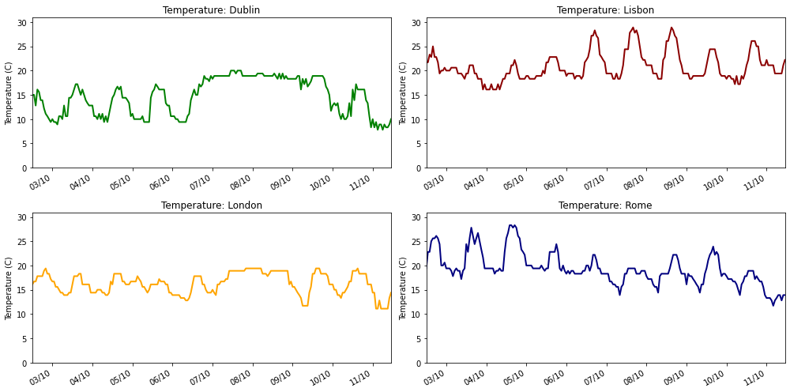

```python
fig = plt.figure(figsize=(14,7))
for i, city_name in enumerate(city_names):
    axc = fig.add_subplot(2, 2, i+1)
    ax = df_cities[city_name]["Temperature"].plot(ax=axc, legend=False, lw=2, color=city_colors[city_name])
    ax.set_title("Temperature: %s" % city_name)
    ax.set_ylabel("Temperature (C)")
    # note that we will use consistent Y-axis limits based on the ranges we computed above
    ax.set_ylim(0, df_temp_stats["Max"].max()+2)
    ax.set_xlim(df_cities[city_name].index.min(), df_cities[city_name].index.max())
    # change the format of the dates on the x-axis
    ax.xaxis.set_major_formatter(mdates.DateFormatter('%d/%m'))
# fix the spacing between plots
fig.tight_layout()
```

From the plots above, we can see daily temperature trends. In some cases the delineation between day and night is quite clear. However, in other cases (e.g. Dublin between 07/10 and 09/10), there is little difference between day-time and night-time temperatures.

We could look at daily trends, such as minimum and maximum values.

Firstly, we group the values for each city by day and use this to create new DataFrames indexed by day:

```python
df_daily_temps = {}
for city_name in city_names:
    # groupy each index by day
    groups = df_cities[city_name]["Temperature"].groupby(pd.Grouper(freq='D'))
    min_temps = groups.min()
    max_temps = groups.max()
    # combine the min and max daily values into a new DataFrame
    df_daily_temps[city_name] = pd.DataFrame({"Min": min_temps, "Max": max_temps})
```

Then we can plot these individually, with comparative bar plots for each city showing the minimum and maximum temperature on each day in our data:

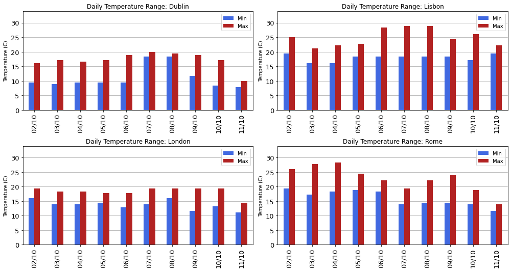

```python
fig = plt.figure(figsize=(14,7.5))
for i, city_name in enumerate(city_names):
    axc = fig.add_subplot(2, 2, i+1)
    ax = df_daily_temps[city_name].plot.bar(ax=axc, y=['Min', 'Max'],
        color={ "Min": "royalblue", "Max": "firebrick"}, fontsize=fontsize, zorder=3)
    # generate nicer x-axis labels
    ticklabels = [ d.strftime("%d/%m") for d in df_daily_temps[city_name].index]
    ax.xaxis.set_major_formatter(ticker.FixedFormatter(ticklabels))
    ax.set_title("Daily Temperature Range: %s" % city_name)
    ax.set_ylabel("Temperature (C)")
    # again make the y-axis ranges consistent
    ax.set_ylim(0, df_temp_stats["Max"].max()+5)
    ax.yaxis.grid(True);
# fix the spacing between plots
fig.tight_layout()
```

Again from the above we see that the day vs night temperature differences are more prounounced in some cases rather than others. For instance, for Dublin there are clear differences between 02/10 and 06/10, but then we see very little variation in temperature on 07/10 and 08/10.

Alternatively, to analyse temperatures we could merge the data from the different cities into a single DataFrame. Again we'll create a convenience function for this so that we can re-use it later.

```python
def merge_data_by_column(col_name):
    columns = {}
    for city_name in city_names:
        columns[city_name] = df_cities[city_name][col_name]
    df_merged = pd.DataFrame(columns).sort_index()
    # note if we have some mismatches on dates between cities, we will drop the rows
    return df_merged.dropna()
```

```python
df_temp_merged = merge_data_by_column("Temperature")
df_temp_merged.head(5)
```

|  | Dublin | Lisbon | London | Rome |
| --- | --- | --- | --- | --- |
| 2021-10-02 12:00:00 | 15.0 | 21.7 | 16.1 | 19.4 |
| 2021-10-02 13:00:00 | 15.0 | 21.7 | 16.7 | 22.8 |
| 2021-10-02 14:00:00 | 12.8 | 23.3 | 16.7 | 22.8 |
| 2021-10-02 15:00:00 | 16.1 | 22.8 | 17.8 | 25.0 |
| 2021-10-02 16:00:00 | 15.6 | 25.0 | 17.8 | 25.6 |

Plot the temperatures over time as a line plot:

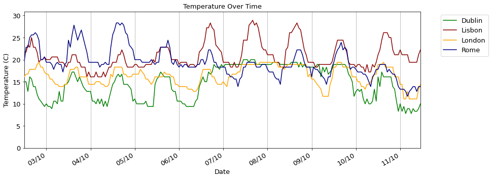

```python
ax = df_temp_merged.plot(figsize=(14,5.5), color=city_colors, fontsize=fontsize, zorder=3)
ax.set_title("Temperature Over Time", fontsize=fontsize)
ax.set_xlabel("Date", fontsize=fontsize)
ax.set_ylabel("Temperature (C)", fontsize=fontsize)
# adjust the axis limits
ax.set_ylim(0, df_temp_stats["Max"].max()+2)
ax.set_xlim(df_temp_merged.index.min(), df_temp_merged.index.max())
# change the format of the dates on the x-axis
ax.xaxis.set_major_formatter(mdates.DateFormatter('%d/%m'))
# move the legend outside the plot
ax.legend(bbox_to_anchor=(1.18, 1), fontsize=fontsize)
# add an x grid
ax.xaxis.grid(True);
```

As we might expect, the above shows that temperatures in Rome and Lisbon are often above those in Dublin and London, although we do see a fall-off in temperatures for Rome later in the data.

To get a smooth curve and a better sense of the trend in terms of temperature, we could compute the rolling 12-hour average:

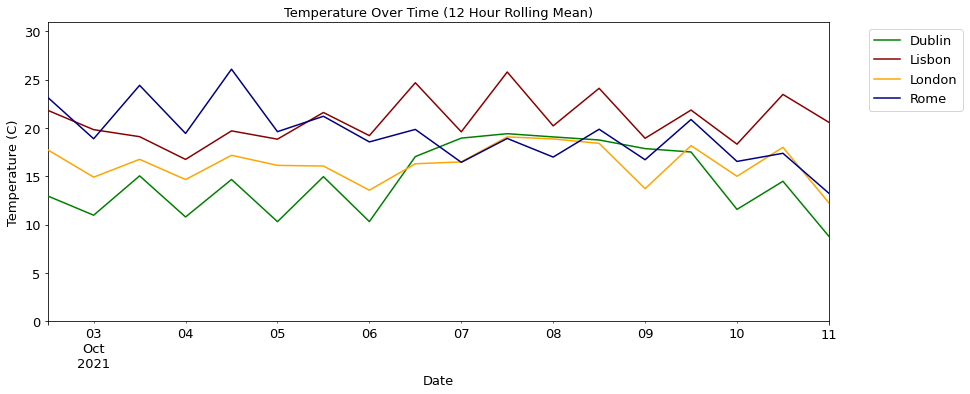

```python
# apply resampling
df_temp_rolling = df_temp_merged.resample('12H').mean()
# plot the resampled time series
ax = df_temp_rolling.plot(figsize=(14, 5.5), color=city_colors, fontsize=fontsize, zorder=3)
ax.set_title("Temperature Over Time (12 Hour Rolling Mean)", fontsize=fontsize)
ax.set_xlabel("Date", fontsize=fontsize)
ax.set_ylabel("Temperature (C)", fontsize=fontsize)
ax.set_ylim(0, df_temp_stats["Max"].max()+2)
# move the legend outside the box
ax.legend(bbox_to_anchor=(1.18, 1), fontsize=fontsize);
```

Using a rolling-mean can give us a somewhat clearer indication of the overall trend in the data. For instance, here we clearly see an increase in temperature for Dulin over a number of days, followed by a fall-off at the end of the time period.

We could also use box plots to examine the distribution of values for temperature for each city:

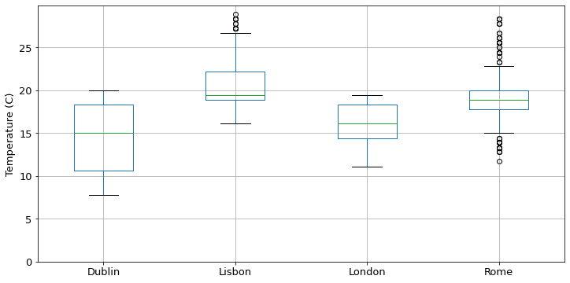

```python
ax = df_temp_merged.boxplot(figsize=(12,6), fontsize=fontsize)
ax.set_ylim(0, df_temp_stats["Max"].max()+1)
ax.set_ylabel("Temperature (C)", fontsize=fontsize);
```

The box plots not only show the median values, but they also provide a clear view of the variation in the temperatures for each city. For instance, we see a number of outliers for Lisbon, indicating particularly high hourly temperatures which are well above the median for that city.

### Precipitation Level Analysis

Next we will look at precipitation levels across the different cities, in terms of number of millimetres of liquid water per hour.

First, we look at the summary statistics. We can use the function we defined previously:

```python
df_precip_stats = compute_stats("PrecipitationLevel")
df_precip_stats
```

| City | Min | Max | Mean | Median |
| --- | --- | --- | --- | --- |
| Dublin | 0.0 | 3.0 | 0.16 | 0.0 |
| Lisbon | 0.0 | 3.0 | 0.05 | 0.0 |
| London | 0.0 | 4.0 | 0.21 | 0.0 |
| Rome | 0.0 | 7.0 | 0.31 | 0.0 |

Next, look at the precipitation level for each city separately:

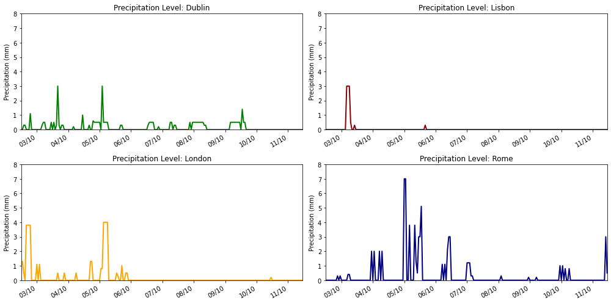

```python
fig = plt.figure(figsize=(14,7))
for i, city_name in enumerate(city_names):
    # create a subplot
    axc = fig.add_subplot(2, 2, i+1)
    # generate the plot for this city
    ax = df_cities[city_name]["PrecipitationLevel"].plot(ax=axc, legend=False, lw=2, color=city_colors[city_name])
    ax.set_title("Precipitation Level: %s" % city_name)
    ax.set_ylabel("Precipitation (mm)")
    # note that we will use consistent Y-axis limits based on the ranges we computed above
    ax.set_ylim(0, df_precip_stats["Max"].max()+1)
    ax.set_xlim(df_cities[city_name].index.min(), df_cities[city_name].index.max())
    # change the format of the dates on the x-axis
    ax.xaxis.set_major_formatter(mdates.DateFormatter('%d/%m'))
# fix the spacing between plots
fig.tight_layout()
```

The above shows frequent light rainfall for Dublin over much of the time in question. Lisbon has little rainfall, while Rome appears to have several periods of heavier rain.

Again we can merge the relevant columns from the city frames into a single DataFrame:

```python
df_precip_merged = merge_data_by_column("PrecipitationLevel")
df_precip_merged.head(5)
```

|  | Dublin | Lisbon | London | Rome |
| --- | --- | --- | --- | --- |
| 2021-10-02 12:00:00 | 0.0 | 0.0 | 1.0 | 0.0 |
| 2021-10-02 13:00:00 | 0.0 | 0.0 | 1.3 | 0.0 |
| 2021-10-02 14:00:00 | 0.3 | 0.0 | 0.5 | 0.0 |
| 2021-10-02 15:00:00 | 0.3 | 0.0 | 0.0 | 0.0 |
| 2021-10-02 16:00:00 | 0.0 | 0.0 | 3.8 | 0.0 |

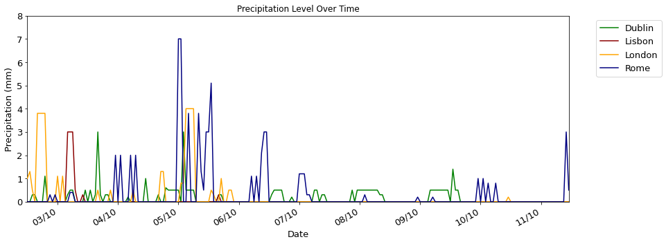

```python
ax = df_precip_merged.plot(figsize=(14, 5.5), color=city_colors,
                           title="Precipitation Level Over Time", fontsize=fontsize, zorder=3)
ax.set_xlabel("Date", fontsize=fontsize)
ax.set_ylabel("Precipitation (mm)", fontsize=fontsize)
ax.set_xlim(df_precip_merged.index.min(), df_precip_merged.index.max())
ax.set_ylim(0, df_precip_stats["Max"].max()+1)
# change the format of the dates on the x-axis
ax.xaxis.set_major_formatter(mdates.DateFormatter('%d/%m'))
# move the legend outside the box
ax.legend(bbox_to_anchor=(1.18, 1), fontsize=fontsize);
```

We can smooth this out using a rolling window. For rainfall, we will use a shorter window than we used for temperatures -- we compute averages on a 6 hour time frame.

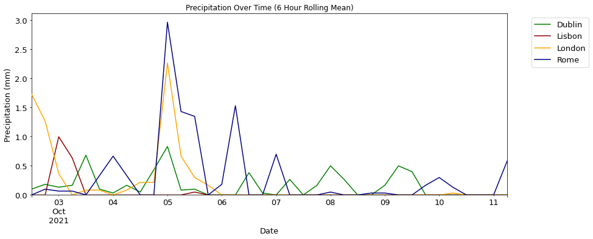

```python
# apply resampling
df_precip_rolling = df_precip_merged.resample('6H').mean()
ax = df_precip_rolling.plot(figsize=(14, 5.5), color=city_colors,
                          title="Precipitation Over Time (6 Hour Rolling Mean)", fontsize=fontsize, zorder=3)
ax.set_xlabel("Date", fontsize=fontsize)
ax.set_ylabel("Precipitation (mm)", fontsize=fontsize)
ax.set_ylim(0)
# move the legend outside the box
ax.legend(bbox_to_anchor=(1.18, 1), fontsize=fontsize);
```

Visually look at the distribution of precipitation for each city:

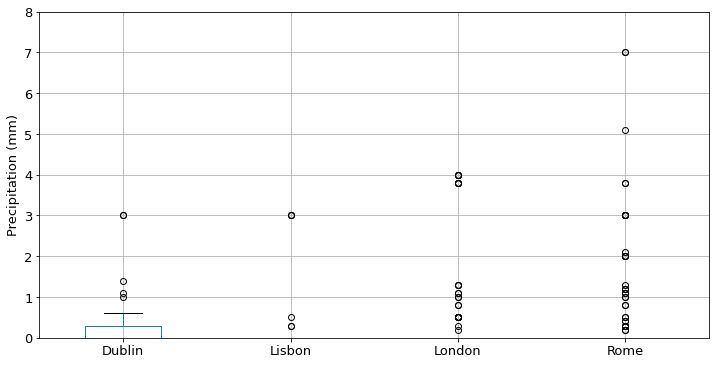

```python
ax = df_precip_merged.boxplot(figsize=(12,6), fontsize=fontsize)
ax.set_ylim(0, df_precip_stats["Max"].max()+1)
ax.set_ylabel("Precipitation (mm)", fontsize=fontsize);
```

In most cases, the median (and mean) rainfall per hour is close to 0mm. However, the boxplots show there is considerable variation here for certain hours, particularly in the case of Rome, as we saw earlier.

We could also look at the percentage of "rainy hours" per city across all of the observations for each city:

```python
# set a very low threshold
precipitation_threshold = 0.1
city_rainy_hours = {}
for city_name in city_names:
    precip = df_cities[city_name]["PrecipitationLevel"]
    # how many rows reach the threshold?
    num_rainy = len(precip[precip>=precipitation_threshold])
    # convert number to percentage
    city_rainy_hours[city_name] = (100.0*num_rainy)/len(precip)
# convert to a Series
rainy_hours = pd.Series(city_rainy_hours)
```

Display the percentages as a bar plot:

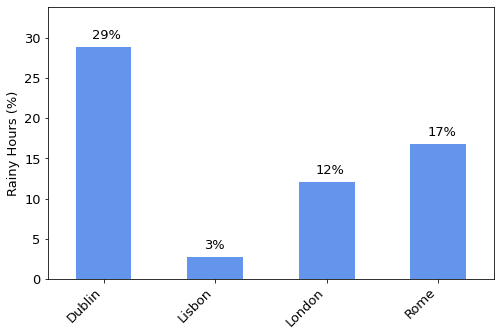

```python
ax = rainy_hours.plot.bar(figsize=(8,5), fontsize=fontsize, color="#6495ed")
ax.set_ylabel("Rainy Hours (%)", fontsize=fontsize)
ax.set_ylim(0, rainy_hours.max() + 5)
# adjust the x-axis label rotation
plt.xticks(rotation=45, ha='right');
# add text labels above the bars to show the percentages
for p in ax.patches:
    b = p.get_bbox()
    val = "{:.0f}%".format(b.y1 + b.y0)
    ax.annotate(val, ((b.x0 + b.x1)/2 + -0.1, b.y1 + 1.0), fontsize=fontsize)
```

Overall, we can see from the above that Dublin had a far higher percentage of hours where at least some rain fell, while Lisbon had very few hours were any rain fell at all.

We could use a more nuanced classification of rain intensity, as described [here](https://en.wikipedia.org/wiki/Rain):

- Light rain — when the precipitation level is < 2.5 mm per hour
- Moderate rain — when the precipitation level is between 2.5 to 7.6 mm per hour
- Heavy rain — when the precipitation level is > 7.6 mm per hour

```python
rows = []
# create a DataFrame with hourly percentage for different rainfall categories
for city_name in city_names:
    row = {"Light":0, "Moderate":0, "Heavy":0}
    for i, value in df_cities[city_name]["PrecipitationLevel"].iteritems():
        if value > 7.6:
            row["Heavy"] += 1
        elif value >= 2.5:
            row["Moderate"] += 1
        # any rain at all?
        elif value > 0.1:
            row["Light"] += 1
    # convert numbers to percentages
    for key in row:
        row[key] = (100.0*row[key])/len(df_cities[city_name])
    row["City"] = city_name
    rows.append(row)
df_rain_levels = pd.DataFrame(rows).set_index("City")
# put the cities on columns
df_rain_levels = df_rain_levels.transpose()
df_rain_levels
```

| City | Dublin | Lisbon | London | Rome |
| --- | --- | --- | --- | --- |
| Light | 27.91 | 1.4 | 8.37 | 12.09 |
| Moderate | 0.93 | 1.4 | 3.72 | 4.65 |
| Heavy | 0.00 | 0.0 | 0.00 | 0.00 |

Display the percentages for each rainfall category as bar charts:

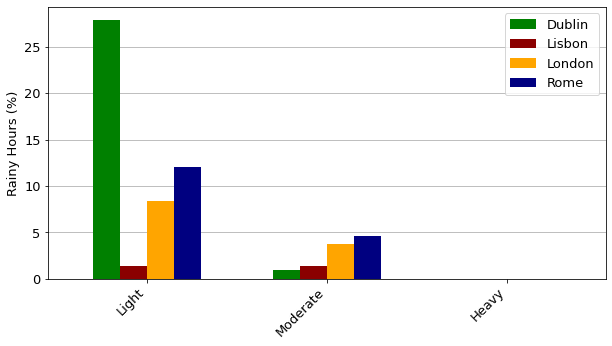

```python
ax = df_rain_levels.plot.bar(figsize=(10,5), width=0.6, fontsize=fontsize, color=city_colors, zorder=3)
ax.legend(fontsize=fontsize)
ax.set_ylabel("Rainy Hours (%)", fontsize=fontsize)
ax.yaxis.grid(True)
# adjust the x-axis label rotation
plt.xticks(rotation=45, ha='right');
```

This more nuanced view of rainfall shows that, although Dublin experienced many more hours where rain fell, most of this was light rain, with far less in the way of 'moderate' rain. None of the cities observed what is considered to be 'heavy' rainfall during the period in question.

### Analysis of Wind Speeds

Look at reported hourly wind speeds, in km/h, for each of the cities:

```python
df_wind_stats = compute_stats("Wind")
df_wind_stats
```

| City | Min | Max | Mean | Median |
| --- | --- | --- | --- | --- |
| Dublin | 3.7 | 35.2 | 16.99 | 14.8 |
| Lisbon | 0.0 | 31.5 | 13.42 | 13.0 |
| London | 2.0 | 47.6 | 13.53 | 11.5 |
| Rome | 1.9 | 33.3 | 14.81 | 14.8 |

Next, look at the wind speed levels for each city separately:

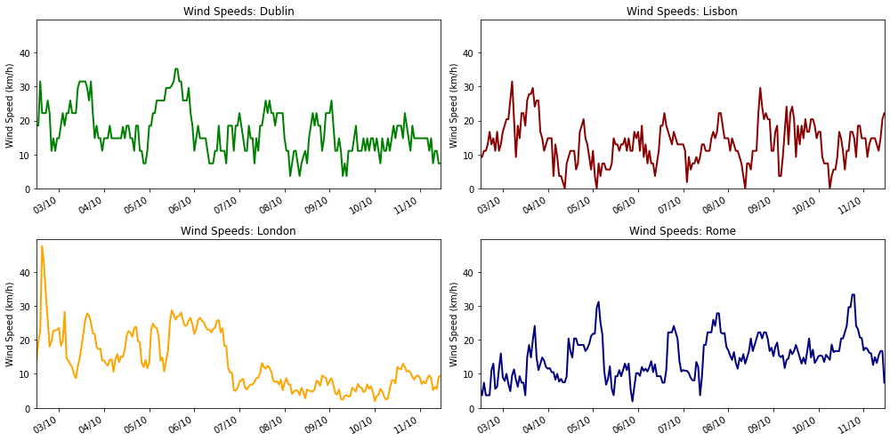

```python
fig = plt.figure(figsize=(14,7))
for i, city_name in enumerate(city_names):
    axc = fig.add_subplot(2, 2, i+1)
    ax = df_cities[city_name]["Wind"].plot(ax=axc, legend=False, lw=2, color=city_colors[city_name])
    ax.set_title("Wind Speeds: %s" % city_name)
    ax.set_ylabel("Wind Speed (km/h)")
    ax.set_ylim(0, df_wind_stats["Max"].max()+2)
    ax.set_xlim(df_cities[city_name].index.min(), df_cities[city_name].index.max())
    # change the format of the dates on the x-axis
    ax.xaxis.set_major_formatter(mdates.DateFormatter('%d/%m'))
# fix the spacing between plots
fig.tight_layout()
```

Again, merge into a single DataFrame:

```python
df_wind_merged = merge_data_by_column("Wind")
df_wind_merged.head(5)
```

|  | Dublin | Lisbon | London | Rome |
| --- | --- | --- | --- | --- |
| 2021-10-02 12:00:00 | 18.5 | 9.3 | 13.5 | 5.6 |
| 2021-10-02 13:00:00 | 18.5 | 9.3 | 19.5 | 3.7 |
| 2021-10-02 14:00:00 | 31.5 | 11.1 | 22.6 | 7.4 |
| 2021-10-02 15:00:00 | 22.2 | 11.1 | 47.6 | 3.7 |
| 2021-10-02 16:00:00 | 22.2 | 13.0 | 42.3 | 3.7 |

Visually look at the distribution of wind speeds for each city using box plots:

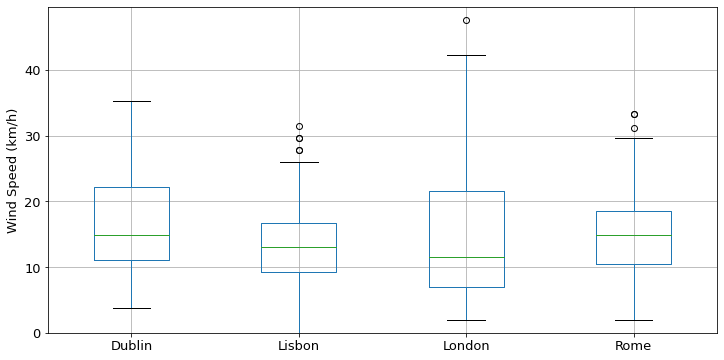

```python
ax = df_wind_merged.boxplot(figsize=(12,6), fontsize=fontsize)
ax.set_ylim(0, df_wind_stats["Max"].max()+2)
ax.set_ylabel("Wind Speed (km/h)", fontsize=fontsize);
```

Again could also look at the percentage of "windy hours" per city across all of the observations for each city, based on some threshold.

We could for instance, consider "windy" to be anything to be Force 5 "Fresh breeze" and above on the *The Beaufort Scale*, which starts at 29km/h:

https://www.met.ie/forecasts/marine-inland-lakes/beaufort-scale

```python
wind_speed__threshold = 29
city_windy_hours = {}
for city_name in city_names:
    precip = df_cities[city_name]["Wind"]
    # how many rows reach the threshold?
    num_windy = len(precip[precip>=wind_speed__threshold])
    # convert number to percentage
    city_windy_hours[city_name] = (100.0*num_windy)/len(precip)
# convert to a Series
windy_hours = pd.Series(city_windy_hours)
```

Display the hour percentages using a bar plot:

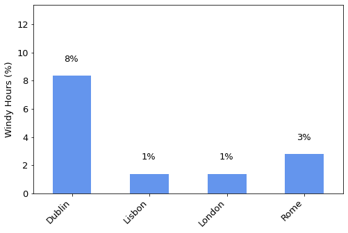

```python
ax = windy_hours.plot.bar(figsize=(8,5), fontsize=fontsize, color="#6495ed")
ax.set_ylabel("Windy Hours (%)", fontsize=fontsize)
ax.set_ylim(0, windy_hours.max() + 5)
# adjust the x-axis label rotation
plt.xticks(rotation=45, ha='right');
# add labels above the bars
for p in ax.patches:
    b = p.get_bbox()
    val = "{:.0f}%".format(b.y1 + b.y0)
    ax.annotate(val, ((b.x0 + b.x1)/2 + -0.1, b.y1 + 1.0), fontsize=fontsize)
```

From the above, we see that the frequency of anything involving a 'fresh breeze' or more was quite rare across all locations during this time period, although Dublin did experience more wind of this kind that the other three cities.

### Correlations Between Cities

Next, we will look at the extent to which the different cities are correlated with one another, under different weather variables. We'll use the merge DataFrames that we created earlier.

We will define a single fuction which computes the pairwise Pearson correlations between the columns (i.e. cities) and displays this as a 'heatmap' visualisation:

```python
import numpy as np
def plot_heatmap(title, df_in, figsize=(5.5, 5)):
    df_corr = df_in.corr()
    # create a color palettte
    cmap = sns.diverging_palette(230, 20, as_cmap=True)
    # display the heatmap
    f, ax = plt.subplots(figsize=figsize)
    sns.heatmap(df_corr, square=True, cbar=False,
                annot=True, cmap=cmap, linewidths=0.5, vmin=-1)
    ax.set_title(title)
```

First, look at the correlation heatmap for temperature:

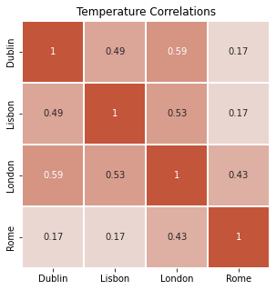

```python
plot_heatmap("Temperature Correlations", df_temp_merged)
```

In terms of temperature correlations, we can see a reasonable level of correlation between Dublin and London, and less so for Lisbon. The correlation between Rome and the other cities is considerably lower.

We could also look at precipitation level:

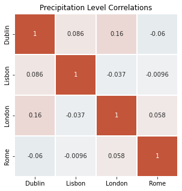

```python
plot_heatmap("Precipitation Level Correlations", df_precip_merged)
```

In this case the correlations across cities are far lower, with a few negative correlations.

Or we could look at another variable, such as percentage cloud cover:

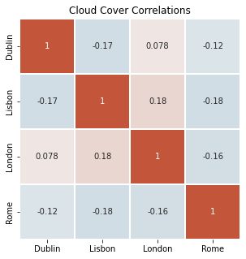

```python
df_cover_merged = merge_data_by_column("CloudCover")
plot_heatmap("Cloud Cover Correlations", df_cover_merged)
```

Again, we see little relation between the cloud cover values across the four cities.

### Correlations Between Variables

Next, we will look at the extent to which the different weather variables are correlated across all cities.

```python
# the columns we will focus on
target_columns = ["Temperature", "WindChillTemperature", "PrecipitationLevel", "Wind", "Humidity", "CloudCover"]
```

Firstly, we will stack all of the DataFrames for the cities into a single DataFrame. Note that, as part of this, we will reset the index of each frame so that we can include duplicate dates (i.e. for different cities).

```python
all_dfs = []
for city_name in city_names:
    all_dfs.append(df_cities[city_name].reset_index())
# concatendate all of the DataFrames into a single stacked frame
df_all = pd.concat(all_dfs)
df_all.head()
```

|  | index | City | Temperature | WindChillTemperature | PrecipitationLevel | Wind | Humidity | CloudCover | Description |
| --- | --- | --- | --- | --- | --- | --- | --- | --- | --- |
| 0 | 2021-10-02 12:00:00 | Dublin | 15.0 | 12.2 | 0.0 | 18.5 | 75 | 0.63 | Light rain |
| 1 | 2021-10-02 13:00:00 | Dublin | 15.0 | 12.2 | 0.0 | 18.5 | 74 | 0.76 | Mostly cloudy |
| 2 | 2021-10-02 14:00:00 | Dublin | 12.8 | 6.7 | 0.3 | 31.5 | 85 | 0.76 | Mostly cloudy |
| 3 | 2021-10-02 15:00:00 | Dublin | 16.1 | 12.8 | 0.3 | 22.2 | 70 | 0.88 | Mostly cloudy |
| 4 | 2021-10-02 16:00:00 | Dublin | 15.6 | 12.8 | 0.0 | 22.2 | 58 | 0.88 | Mostly cloudy |

Now only keep the target values columns of interest:

```python
df_all2 = df_all[target_columns]
df_all2.head()
```

|  | Temperature | WindChillTemperature | PrecipitationLevel | Wind | Humidity | CloudCover |
| --- | --- | --- | --- | --- | --- | --- |
| 0 | 15.0 | 12.2 | 0.0 | 18.5 | 75 | 0.63 |
| 1 | 15.0 | 12.2 | 0.0 | 18.5 | 74 | 0.76 |
| 2 | 12.8 | 6.7 | 0.3 | 31.5 | 85 | 0.76 |
| 3 | 16.1 | 12.8 | 0.3 | 22.2 | 70 | 0.88 |
| 4 | 15.6 | 12.8 | 0.0 | 22.2 | 58 | 0.88 |

One way to look at the relationship between a set of columns of interest would be to produce a *scatter matrix*:

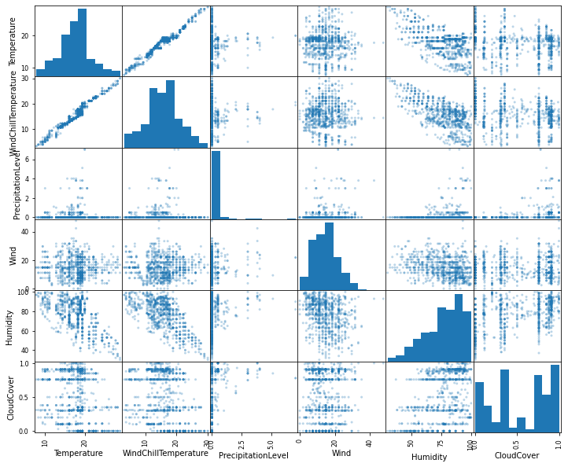

```python
ax = scatter_matrix(df_all2, figsize=(12,10), alpha=0.3)
```

However, this is quite difficult to interpret. So instead we could produce correlation heatmaps, like we did previously when comparing the cities:

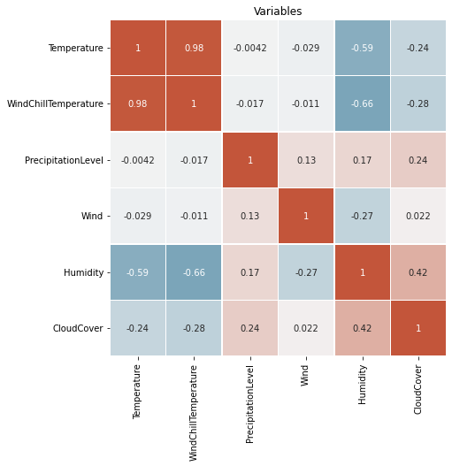

```python
plot_heatmap("Variables", df_all2, figsize=(11,7))
```

As we might expect, by far the strongest correlation is between raw temperature and temperature adjust for wind-chill factor. In contrast, humidity is quite strongly negatively correlated with temperature, although it does correspond to level of cloud cover, as we might expect.

### Weather Text Descriptions

Finally we will look at the textual descriptions that AccuWeather provides with each hourly observation (e.g. 'mostly clear', 'partly cloudy' etc).

We'll look at the percentage times with which each description appears for each city.

```python
text_counts = {}
for city_name in city_names:
    counts = df_cities[city_name]["Description"].value_counts()
    # convert to percentage
    text_counts[city_name] = (counts*100.0)/len(df_cities[city_name])
# convert to a DataFrame and fill the missing value with 0s
# i.e. descriptions which don't appear for a given city
df_text_counts = pd.DataFrame(text_counts).fillna(0)
df_text_counts
```

|  | Dublin | Lisbon | London | Rome |
| --- | --- | --- | --- | --- |
| A shower | 0.00 | 0.00 | 0.00 | 4.65 |
| Clear | 0.47 | 21.86 | 8.84 | 6.05 |
| Clouds and sun | 0.00 | 0.00 | 0.00 | 1.40 |
| Cloudy | 19.53 | 4.19 | 28.84 | 6.51 |
| Drizzle | 0.00 | 0.00 | 0.47 | 0.00 |
| Fog | 3.26 | 0.93 | 3.72 | 0.00 |
| Heavy rain | 0.00 | 0.00 | 0.00 | 0.47 |
| Light rain | 11.16 | 0.93 | 5.12 | 0.47 |
| Mostly clear | 4.65 | 7.91 | 5.58 | 2.33 |
| Mostly cloudy | 43.72 | 20.47 | 23.26 | 13.95 |
| Mostly sunny | 0.93 | 11.16 | 8.37 | 2.33 |
| Partly cloudy | 11.16 | 6.98 | 4.65 | 12.56 |
| Partly sunny | 4.19 | 4.19 | 4.65 | 16.28 |
| Rain | 0.93 | 0.00 | 3.72 | 3.26 |
| Some clouds | 0.00 | 0.00 | 0.00 | 10.70 |
| Sunny | 0.00 | 21.40 | 2.79 | 14.88 |
| Thunderstorm | 0.00 | 0.00 | 0.00 | 4.19 |

We could simply look at the most frequent description for each city:

```python
df_text_counts.idxmax()
```

```
Dublin    Mostly cloudy
Lisbon            Clear
London           Cloudy
Rome       Partly sunny
dtype: object
```

So for instance, Dublin is most frequently 'Mostly cloudy' during this time period, while Lisbon is most frequently 'Clear'.

We could visually present this all of the frequency information using bar plots:

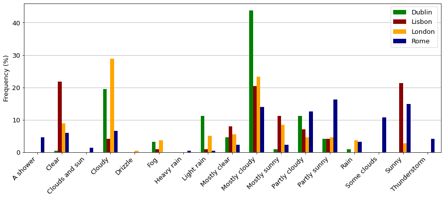

```python
ax = df_text_counts.plot.bar(figsize=(15,5.5), width=0.6, fontsize=fontsize, color=city_colors, zorder=3)
ax.legend(fontsize=fontsize)
ax.set_ylabel("Frequency (%)", fontsize=fontsize)
ax.yaxis.grid(True)
# adjust the x-axis label rotation
plt.xticks(rotation=45, ha='right');
```

Alternatively, to make this a little clearer, we might choose to use a heatmap representation to disply the full set of percentages for the different text descriptions:

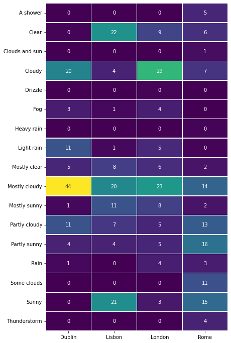

```python
# create a color palettte
cmap = sns.color_palette("viridis", as_cmap=True)
# display the heatmap, with percentages rounded to nearest integer
f, ax = plt.subplots(figsize=(6.5,12))
h = sns.heatmap(df_text_counts, square=False, cbar=False,
            annot=True, fmt='.0f', cmap=cmap, linewidths=0.5, vmin=0)
```

We could view these values for the weather descriptions as providing a numeric profile or set of features for describing the weather in each of these cities.

We could measure the similarity or distance between these profiles, using a standard measure such as Euclidean distance:

```python
X = df_text_counts.transpose()
D = euclidean_distances(X)
D
```

```
array([[ 0.        , 43.99714824, 26.96070092, 41.83461734],
       [43.99714824,  0.        , 34.48767425, 28.18466494],
       [26.96070092, 34.48767425,  0.        , 34.28635813],
       [41.83461734, 28.18466494, 34.28635813,  0.        ]])
```

From these distance values, for each city we could find the most similar (least distant) and least similar (most distant) other city:

```python
print("-- Weather profiles")
for i, city_name in enumerate(city_names):
    dmin, dmax = 0, 0
    city_min, city_max = None, None
    for j in range(len(city_names)):
        # skip the diagonal
        if i == j:
            continue
        if city_min is None or D[i,j] < dmin:
            dmin = D[i,j]
            city_min = city_names[j]
        if city_max is None or D[i,j] > dmax:
            dmax = D[i,j]
            city_max = city_names[j]
    print("%s\t Most similar to %s, least similar to %s" % (city_name, city_min, city_max))
```

```
-- Weather profiles
Dublin	 Most similar to London, least similar to Lisbon
Lisbon	 Most similar to Rome, least similar to Dublin
London	 Most similar to Dublin, least similar to Lisbon
Rome	 Most similar to Lisbon, least similar to Dublin
```

As we might expect, the profiles for Dublin and London are most similar to one another, with the other two more southerly cities are more similar (both sometimes referred to as having warm-temperate Mediterranean climates).

## Task 3 - Discussion and Conclusions

In this assignment we looked at the analysis of hourly data for four locations, focusing particularly on temperature, precipitation, and wind speeds. As we might expect, the weather patterns for Dublin and London were similar to some extent, and certainly Dublin experienced quite different conditions from Rome and Lisbon during the time period that we studied.

One particular challenge of using the free AccuWeather API is that historic data only covers the previous 24 hour period, which meant that the data collection process had to be repeated many times to build up an initial raw dataset. To perform more longitudinal climate analysis would required data to be acquired over an extended period of time. A considerable level of data preprocessing was also required to merge the raw data into a single dataset for each city.

A number of interesting avenues could be considered for further analysis of this data:

- The analysis could be extended to a larger number of cities to further investigated the idea of 'weather profiles' based on text descriptions.
- If further historic data was available, we could consider whether the weather observed in our data was in line with seasonal norms.
- Again if we had further historic data, we could experiment with time series forecasting methods to attempt to make predictions for variables like hourly temperature.